# Assessing and Addressing Fairness in a Predictive Model of Medical Expenditure

July 18 2023

This notebook is based on the python tutorial from IBM’s [AIF360](https://nbviewer.org/github/IBM/AIF360/blob/master/examples/tutorial_medical_expenditure.ipynb)

# Dataset

The dataset used in this tutoral was adapted from the [‘Medical Expenditure Panel Survey’](https://meps.ahrq.gov/mepsweb/).

- The specific data used is the 2015 Full Year Consolidated Data File (h181.csv) as well as the 2016 Full Year Consolidated Data File (h192.csv).
- The 2015 file contains data from rounds 3,4,5 of panel 19 (2014) and rounds 1,2,3 of panel 20 (2015).
- The 2016 file contains data from rounds 3,4,5 of panel 20 (2015) and rounds 1,2,3 of panel 21 (2016).
- The panel 19 dataset is split into 3 parts: a train, a validation, and a test/deployment part.
- The panel 21 data is used for testing data/concept drift after model training.
- For each dataset, the sensitive attribute is ‘RACE’ consisting of ‘Whites’ defined by the features RACEV2X = 1 (White) and HISPANX = 2 (non Hispanic) and ‘Non-Whites’ that included everyone else.
- Our modelling goal is to predict ‘high’ utilization. To measure utilization, the total number of trips requiring some sort of medical care was recorded. Respondents were considered to have high utilization if they had 10 or more visits (~17%).

# Tidymodels

The [`tidymodels`](https://www.tidymodels.org/packages/) collection of R packages simplifies and standardizes the process of modeling and machine learning in R by providing a consistent framework that integrates with the tidyverse. It emphasizes tidy data principles and offers a wide range of modeling techniques, tuning, and evaluation functionalities.

The idea is to specify `recipes` that simplify the pre and post processing steps typially used in predicitive modeling (or model fitting in general).

# Downloading and Preprocessing data

**Documentation:**

https://github.com/Trusted-AI/AIF360/blob/master/aif360/data/raw/meps/README.md

Make sure to read and abide by the data use agreements in the above link.

Download and run the data preparation script

```bash
curl https://raw.githubusercontent.com/Trusted-AI/AIF360/master/aif360/data/raw/meps/generate_data.R --output generate_data.R

Rscript generate_data.R
```

Additional setup for aif360

```bash
conda create -n aif360 python=3 pip
conda activate aif360
pip install aif360
```

## 1. Load required libraries and Panel 19 data

```r
library(ggplot2)
library(patchwork)
library(skimr)

library(knitr)
library(rmarkdown)
library(pander)

#optional
library(reticulate)
use_condaenv("aif360")

source("helpers.R")

meps_19 <- process_meps_csv("h181.csv", 19)

#optional
readr::write_csv(meps_19, file="h181-processed.csv")
```

## 2. Create training/validation/testing model splits

As in the aif360 tutorial we will split MEPS 19 into train (50%), validate (30%), and test (20%)

However, because `high_utilization` is unbalanced, we will use it as a stratification factor to ensure equal representation among the splits

```r
meps_19 %>%
  count(high_utilization) %>%
  mutate(prop = n/sum(n)) %>%
  kable()
```

| high_utilization | n | prop |
| --- | --- | --- |
| low | 13112 | 0.8283007 |
| high | 2718 | 0.1716993 |

Additionally, since we first want direct access to the training dataset for reweighting, we will split 50/50 and further split the *test* dataset into validation/test.

*NOTE:* This is not the **typical** workflow due to the apparent need to define the case weights outside of the pre-processing recipe:

https://www.tidyverse.org/blog/2022/05/case-weights/

```r
set.seed(123)
meps_19_split <- initial_split(meps_19, strata = high_utilization, prop=.5)
```

We can now carry out fairness re-weighing applied to training set only

```r
meps_19_train <- training(meps_19_split)

#R-version from helpers.R
meps_19_train <- reweight(
  meps_19_train,
  "high_utilization",
  "RACE")

#What do these weights look like?
meps_19_train %>%
  group_by(
    high_utilization,
    RACE
  ) %>%
  summarize(
    n(),
    #only the first as the weights are define per combination of outcome/feature
    instance_weights[1]
  ) %>%
  kable()
```

| high_utilization | RACE | n() | instance_weights[1] |
| --- | --- | --- | --- |
| low | Non-White | 4486 | 0.9427783 |
| low | White | 2070 | 1.1240080 |
| high | Non-White | 620 | 1.4140269 |
| high | White | 739 | 0.6526432 |

Alternatively can use the python version

```python
from aif360.sklearn.preprocessing import Reweighing
```

```
## WARNING:root:No module named 'rpy2': FairAdapt will be unavailable. To install, run:
## pip install 'aif360[FairAdapt]'
## WARNING:root:No module named 'torch': LearnedFairRepresentations will be unavailable. To install, run:
## pip install 'aif360[LFR]'
```

```python
import pandas as pd

reweighing_obj = Reweighing(prot_attr='RACE')

inp_df = r.meps_19_train.set_index('RACE', drop=False)

python_weights = reweighing_obj.fit_transform(X=inp_df, y=r.meps_19_train.high_utilization)[0]

python_weights.reset_index(drop=True, inplace=True)

python_weights.groupby(['high_utilization', 'RACE']).agg({'instance_weights':'first'})
```

```
##                             instance_weights
## high_utilization RACE
## low              Non-White          0.942778
##                  White              1.124008
## high             Non-White          1.414027
##                  White              0.652643
```

With the training dataset in hand, we will now form testing/validation splits.

```r
meps_19_inital_test <- testing(meps_19_split)

#As we only need the weights for the training data, set to NA for clarity
meps_19_inital_test$instance_weights <- NA_real_

set.seed(4353)
meps_19_tv_split <- initial_split(meps_19_inital_test, strata = high_utilization, prop=.6)

#To keep things more organized
meps_19_splits <- list(
  training = meps_19_train,
  validation = training(meps_19_tv_split),
  testing = testing(meps_19_tv_split)
)

rm(meps_19_train, meps_19_tv_split)

#Summarize the data splits

bind_rows(lapply(meps_19_splits, function(x){
  x %>%
  count(high_utilization) %>%
  mutate(
    prop = n/sum(n),
    total = sum(n)) %>%
  pivot_wider(id_cols = total, names_from = high_utilization, values_from = prop)
}), .id="split") %>%
kable()
```

| split | total | low | high |
| --- | --- | --- | --- |
| training | 7915 | 0.8283007 | 0.1716993 |
| validation | 4748 | 0.8283488 | 0.1716512 |
| testing | 3167 | 0.8282286 | 0.1717714 |

## 3. Learning a Logistic Regression (elastic net) classifier

We will fit two versions of the model, one without and one with the weights

*NOTE:* We are using the same variables as the AIF360 python tutorial but some additional feature selection and engineering would probably be useful.

For instance:

1. How best to deal with feature encoding, including presence of -1 which indicates ‘Inapplicable’
2. Over-specified categories such as the presence of SEX=1 and SEX=2, either of which can be derived from each other.
3. In addition to terms of use, the variables are defined [here](https://meps.ahrq.gov/data_stats/download_data/pufs/h181/h181doc.shtml#Data)

With that in mind we will train an initial unweighted version

### 3.1 Original (unweighted) classifier

```r
#specify model and fitting backend

lr_mod <-
  logistic_reg(penalty = tune(), mixture = tune()) %>%
  set_engine("glmnet")

#get pre-specified recipe from helpers.R

lr_recipe <- meps_base_recipe(meps_19_splits$training)

#add recipe to a workflow

lr_workflow <-
  workflow() %>%
  add_model(lr_mod) %>%
  add_recipe(lr_recipe)

#To use tune_grid, need to form training/validation sets, note this is not the standard workflow
#which is `validation_split` of the training dataset.

#Here we will form the sets manually

train_val_sets <-
  make_splits(meps_19_splits$training, assessment=meps_19_splits$validation) %>%
  lst %>%
  manual_rset(ids="Validation")

set.seed(9534)

#Performs the actual tuning with respect to the validation set, we will measure balanced accuracy here
#for comparison with the aif360 tutorial.

#note that control_grid is needed to save probabilities for downstream assessement
#in addition to balanced accuracy, we also collect area under the ROC curve as that
#also forces `tune_grid` to save probabilities
lr_res <-
  lr_workflow %>%
  tune_grid(train_val_sets,
            grid = 10,
            control=control_grid(save_pred = TRUE),
            metrics = metric_set(bal_accuracy, roc_auc))

#Simply choose the parameters that give the best accuracy
lr_best <-
  lr_res %>%
  select_best(metric = "bal_accuracy")

lr_best %>% kable()
```

| penalty | mixture | .config |
| --- | --- | --- |
| 2e-07 | 0.6020156 | Preprocessor1_Model06 |

#### 3.1.1 Assess alternate probability cutoffs

By ‘default’ the probability cutoff is usually .5. Especially as our data is unbalanced, we can also examine other possible cutoffs with respect to balanced accuracy and our measure of fairness: **disparate impact**.

```r
lr_stats <-
  lr_res %>%
  collect_predictions(parameters = lr_best)

#get ahold of the validation set annotated with predicted probabilities
#also ensure the protected variable (RACE) is encoded as a factor with
#non-protected level, protected level.
meps_validation_results <-
  bind_cols(
    assessment(train_val_sets$splits[[1]]),
    select(lr_stats, .pred_high, .pred_low, .pred_class)
  ) %>%
  mutate(
    RACE = factor(RACE, levels=c("White", "Non-White"))
  )

validation_probs_thresh <-
  alternate_cutoff_stats(
    meps_validation_results,
    outcome="high_utilization",
    protected_feature="RACE"
  )

#Choose the best one
best_acc = validation_probs_thresh %>%
  arrange(-balanced_accuracy) %>%
  head(n=1)
```

Examine confusion matrices for default prediction cutoffs

```r
validation_preds_by_race <- group_split(meps_validation_results, RACE)
#since list names are not supplied by `group_split`
names(validation_preds_by_race) <- sapply(validation_preds_by_race, function(x) x$RACE[1])

lapply(validation_preds_by_race, function(x){
  conf_mat(x, .pred_class, high_utilization, dnn=c("Utilization", "Predicted Utilization"))
})
```

```
## $White
##            Predicted Utilization
## Utilization  low high
##        low  1219   94
##        high  228  203
##
## $`Non-White`
##            Predicted Utilization
## Utilization  low high
##        low  2559   61
##        high  264  120
```

```r
table(validation_preds_by_race$White$high_utilization)
```

```
##
##  low high
## 1313  431
```

Better accuracy is achieved if we choose a lower cutoff

```r
bind_rows(
  filter(validation_probs_thresh, p_cutoff == .5),
  best_acc
) %>% kable()
```

| balanced_accuracy | p_cutoff | White | Non-White | disparate_impact |
| --- | --- | --- | --- | --- |
| 0.6784544 | 0.5000000 | 0.1702982 | 0.0602530 | 0.3538088 |
| 0.7775483 | 0.1734694 | 0.4420872 | 0.2053928 | 0.4645980 |

```r
#Add to our summary table
best_params = bind_cols(
  version="Original",
  best_acc,
  lr_best
)

best_params %>% kable()
```

| version | balanced_accuracy | p_cutoff | White | Non-White | disparate_impact | penalty | mixture | .config |
| --- | --- | --- | --- | --- | --- | --- | --- | --- |
| Original | 0.7775483 | 0.1734694 | 0.4420872 | 0.2053928 | 0.464598 | 2e-07 | 0.6020156 | Preprocessor1_Model06 |

Note that although the balanced accuracy is **OK**, the disparate impact measure shows room for improvement as we are aiming for a value closer to 1.0. To get closer to reaching this goal we can turn to the relatively simple approach utilizing different weights for each outcome and protected feature category. We saw this in Section 2.

### 3.2. Increasing classifier fairness by reweighting

For case-weights to work with `tidymodels`, they need to be (re)defined by passing them to the `importance_weights()` function. The defined recipe will automatically detect them. See this [reference](https://recipes.tidymodels.org/reference/case_weights.html) for more info.

```r
meps_19_splits_rw <- lapply(meps_19_splits, function(x){
  mutate(x, instance_weights = importance_weights(instance_weights))
})

lr_recipe_rw <- meps_base_recipe(meps_19_splits_rw$training, addtl_vars="instance_weights")

#Verify that this worked

filter(
  lr_recipe_rw$var_info,
  role != "predictor"
) %>% kable()
```

| variable | type | role | source |
| --- | --- | --- | --- |
| high_utilization | factor , unordered, nominal | outcome | original |
| instance_weights | case_weights | case_weights | original |

In addition, the case weights also need to be added to the workflow using the `add_case_weights` function.

```r
lr_workflow_rw <-
  workflow() %>%
  add_model(lr_mod) %>%
  add_recipe(lr_recipe_rw) %>%
  add_case_weights(instance_weights)

#Unforunately we can't re-use existing training/validation sets as they need to have the defined weight column

train_val_sets_rw <-
  make_splits(meps_19_splits_rw$training, assessment=meps_19_splits_rw$validation) %>%
  lst %>%
  manual_rset(ids="Reweighted Validation")

set.seed(9534)

#As before, control_grid is needed to save probabilities for downstream assessement
lr_res_rw <-
  lr_workflow_rw %>%
  tune_grid(train_val_sets_rw,
            grid = 10,
            control=control_grid(save_pred = TRUE),
            metrics = metric_set(bal_accuracy, roc_auc))

#Choosing the best model parameters based on balanced accuracy
lr_best_rw <-
  lr_res_rw %>%
  select_best(metric = "bal_accuracy")

lr_best_rw %>% kable()
```

| penalty | mixture | .config |
| --- | --- | --- |
| 0 | 0.9359681 | Preprocessor1_Model10 |

#### 3.2.1 Assess alternate probability cutoffs

As before we will assess alternative probability cutoffs with respect to balanced accuracy and fairness as measured by disparate impact.

```r
lr_stats_rw <-
  lr_res_rw %>%
  collect_predictions(parameters = lr_best_rw)

#get ahold of the validation set

meps_validation_results_rw <-
  bind_cols(
      assessment(train_val_sets_rw$splits[[1]]),
      select(
        lr_stats_rw,
        .pred_high,
        .pred_low,
        .pred_class)
  ) %>%
  mutate(
    RACE = factor(RACE, levels=c("White", "Non-White")
  )
)

validation_probs_thresh_rw <-
  alternate_cutoff_stats(
    meps_validation_results_rw,
    outcome="high_utilization",
    protected_feature="RACE"
  )

best_acc_rw = validation_probs_thresh_rw %>%
  arrange(-balanced_accuracy) %>%
  head(n=1)

best_params_rw = bind_cols(
  version="Reweighted",
  best_acc_rw,
  lr_best_rw
)

comb_params <- bind_rows(
  best_params,
  best_params_rw
)

comb_params %>% kable()
```

| version | balanced_accuracy | p_cutoff | White | Non-White | disparate_impact | penalty | mixture | .config |
| --- | --- | --- | --- | --- | --- | --- | --- | --- |
| Original | 0.7775483 | 0.1734694 | 0.4420872 | 0.2053928 | 0.4645980 | 2e-07 | 0.6020156 | Preprocessor1_Model06 |
| Reweighted | 0.7615810 | 0.1836735 | 0.3113532 | 0.2629827 | 0.8446442 | 0e+00 | 0.9359681 | Preprocessor1_Model10 |

## 4. Visualize relationship between balanced accuracy and disparate impact

Since we have both a standard classifier and one utilizing fairness weights we can compare their results visually

```r
comb_orig_rw_thresh <- bind_rows(
  mutate(validation_probs_thresh, version="Original"),
  mutate(validation_probs_thresh_rw, version="Reweighted")
)
```

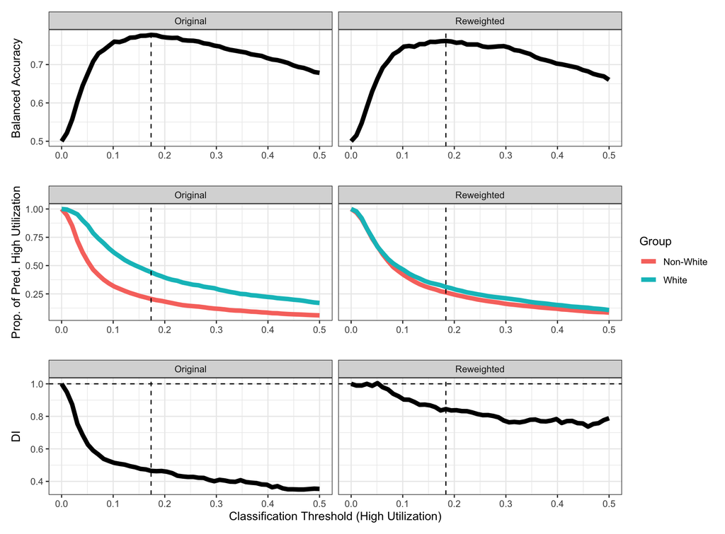

```r
#the 1-p_cutoff refers to the issue that we want to calibrate for the high/less frequent class, but the calibrations were
#done for the base level or low class
p0 <- ggplot(data=comb_orig_rw_thresh, mapping=aes(x=p_cutoff, y=balanced_accuracy)) +
  geom_line(linewidth=2) +
  geom_vline(data=comb_params, mapping=aes(xintercept = p_cutoff), linetype="dashed") +
  facet_wrap(~version, ncol=2) +
  theme_bw() +
  xlab("") +
  ylab("Balanced Accuracy")

decons_di <- pivot_longer(data=comb_orig_rw_thresh, cols=`White`:disparate_impact)

p1 <- ggplot(data=filter(decons_di, name != "disparate_impact"), mapping=aes(x=p_cutoff, y=value, group=name, color=name)) +
  geom_line(linewidth=2) +
  geom_vline(data=comb_params, mapping=aes(xintercept = p_cutoff), linetype="dashed") +
  scale_color_discrete(name="Group") +
  facet_wrap(~version, ncol=2) +
  theme_bw() +
  xlab("") +
  ylab("Prop. of Pred. High Utilization")

p2 <- ggplot(data=filter(decons_di, name == "disparate_impact"), mapping=aes(x=p_cutoff, y=value)) +
  geom_line(linewidth=2) +
  geom_hline(yintercept=1, linetype="dashed") +
  geom_vline(data=comb_params, mapping=aes(xintercept = p_cutoff), linetype="dashed") +
  facet_wrap(~version, ncol=2) +
  theme_bw() +
  xlab("Classification Threshold (High Utilization)") +
  ylab("DI")

p0 / p1 / p2
```

## 5. Application to test set

Assuming we are happy with the performance of this model in the validation set, we can fit to the entire training set and evaluate the final performance on the test dataset.

Note that because we formed the splits outside of `tidymodels` this is a slightly more complex procedure than simply calling `last_fit`.

```r
#Here we need to specify the actual optimal parameters we want to use for the model
lr_mod_rw <- lr_mod %>%
  update(parameters=
           select(
              filter(
                comb_params,
                version == "Reweighted"
              ),
              penalty,
              mixture
              ))

#Add this new model to the workflow, replacing the old version with placeholder variables
#used for tuning
lr_workflow_rw <-
  lr_workflow_rw %>%
  update_model(lr_mod_rw)

#Fit the model
lr_rw_trained <-
  lr_workflow_rw %>%
  fit(data = meps_19_splits_rw$training)

#Determine predictions for the test data for final assessment
lr_rw_test_aug <-
  augment(
    lr_rw_trained,
    meps_19_splits_rw$testing
  ) %>%
  mutate(
    RACE = factor(RACE, levels=c("White", "Non-White"))
  )

#Finally, using the optimal probability cutoffs we will compute the corresponding
#balanced accuracy and
lr_testing_results_rw <- cutoff_stats(
  lr_rw_test_aug,
  cutoff=filter(comb_params,
                version == "Reweighted")$p_cutoff,
  outcome="high_utilization",
  protected_feature="RACE"
  )

test_params_rw = cbind(version="Test",lr_testing_results_rw, lr_best_rw)

comb_params <- bind_rows(comb_params, test_params_rw)

comb_params %>% kable()
```

| version | balanced_accuracy | p_cutoff | White | Non-White | disparate_impact | penalty | mixture | .config |
| --- | --- | --- | --- | --- | --- | --- | --- | --- |
| Original | 0.7775483 | 0.1734694 | 0.4420872 | 0.2053928 | 0.4645980 | 2e-07 | 0.6020156 | Preprocessor1_Model06 |
| Reweighted | 0.7615810 | 0.1836735 | 0.3113532 | 0.2629827 | 0.8446442 | 0e+00 | 0.9359681 | Preprocessor1_Model10 |
| Test | 0.7494264 | 0.1836735 | 0.3254760 | 0.2441860 | 0.7502429 | 0e+00 | 0.9359681 | Preprocessor1_Model10 |

Application to the testing dataset shows dips in both balanced accuracy and disparate impact, so it is both less accurate and less fair.

## 5. Assessing data/concept drift

Given that the data was trained from panel 19, we can also evaluate its performance on other subsets of the data such as panel 21. Decreases in perfomance and/or fairness indicates we need to retrain the model.

Read in and prepare panel 21. In this case it is derived from another file, so we should take care to ensure that it is comparable.

```r
meps_21 <- process_meps_csv("h192.csv", 21)

#also add in placeholder `instance_weights` column

meps_21 <- mutate(
  meps_21,
  instance_weights=importance_weights(NA_real_)
)
```

Since we are using a pre-processing recipe it should fail if columns are missing, additionally we could implement type checks as part of the recipe. Finally, below we can examine how similar panel 21 is to the portion of panel 19 used for training by comparing the computed values.

```r
#We use the `prep` and `bake` functions to apply the specific pre-processing recipe and
#retrieve the input data in the same form as provided to the model

meps_19_prepped <-
  prep(
    lr_recipe_rw,
    training = meps_19_splits_rw$training
  )

meps_19_baked <- bake(meps_19_prepped, new_data=NULL)

#Note that the factor `high_utilization` is not particulary useful in this plot
#this just simplifies plotting
meps_19_skim <- skim(
  meps_19_baked,
  -instance_weights,
  -high_utilization
) %>% partition()

#apply the same transformations to meps_21 and create a summary table
meps_21_baked <- bake(meps_19_prepped, new_data = meps_21)

meps_21_skim <- skim(
  meps_21_baked,
  -instance_weights,
  -high_utilization
) %>% partition()

#Note, the use of a `full_join` here will show any differences in columns
numeric_combined_skim <- full_join(
  as_tibble(meps_19_skim$numeric),
  as_tibble(meps_21_skim$numeric),
  by=c("skim_variable"),
  suffix = c(".19", ".21"),
)

select(
  numeric_combined_skim,
  skim_variable,
  mean.19, mean.21,
  sd.19, sd.21,
  p0.19, p0.21,
  p25.19, p25.21,
  p50.19, p50.21,
  p75.19, p75.21,
  p100.19, p100.21,
  hist.19, hist.21
) %>% paged_table()
```

| skim_variable | mean.19 | mean.21 | sd.19 | sd.21 | p0.19 | p0.21 | p25.19 | p25.21 | p50.19 | p50.21 | p75.19 | p75.21 | p100.19 | p100.21 | hist.19 | hist.21 |
| --- | --- | --- | --- | --- | --- | --- | --- | --- | --- | --- | --- | --- | --- | --- | --- | --- |
| AGE | 3.485812e+01 | 35.713301435 | 22.43318123 | 22.80948605 | 0 | 0 | 15 | 16 | 33.00 | 34.00 | 52.000 | 54.00 | 85.00 | 85.00 | ▇▇▆▅▂ | ▇▆▆▅▃ |
| PCS42 | 2.906211e+01 | 29.713726316 | 26.01920699 | 25.86846147 | -9 | -9 | -1 | -1 | 38.64 | 39.79 | 54.800 | 54.80 | 72.07 | 70.51 | ▇▁▂▆▅ | ▇▁▂▅▆ |
| MCS42 | 3.049553e+01 | 31.381096013 | 26.94276321 | 26.89784339 | -9 | -9 | -1 | -1 | 41.81 | 43.55 | 56.475 | 56.74 | 75.51 | 75.64 | ▇▁▂▇▃ | ▇▁▂▇▃ |
| K6SUM42 | 1.304864e+00 | 1.261435407 | 3.98644663 | 3.88308988 | -9 | -9 | -1 | -1 | 0.00 | 0.00 | 2.000 | 2.00 | 24.00 | 24.00 | ▁▇▁▁▁ | ▁▇▁▁▁ |
| REGION_X1 | 1.416298e-01 | 0.156491228 | 0.34869209 | 0.36333200 | 0 | 0 | 0 | 0 | 0.00 | 0.00 | 0.000 | 0.00 | 1.00 | 1.00 | ▇▁▁▁▁ | ▇▁▁▁▂ |
| REGION_X2 | 1.809223e-01 | 0.196427432 | 0.38497811 | 0.39730815 | 0 | 0 | 0 | 0 | 0.00 | 0.00 | 0.000 | 0.00 | 1.00 | 1.00 | ▇▁▁▁▂ | ▇▁▁▁▂ |
| REGION_X3 | 3.868604e-01 | 0.380669856 | 0.48706201 | 0.48556705 | 0 | 0 | 0 | 0 | 0.00 | 0.00 | 1.000 | 1.00 | 1.00 | 1.00 | ▇▁▁▁▅ | ▇▁▁▁▅ |
| REGION_X4 | 2.905875e-01 | 0.266411483 | 0.45406217 | 0.44209600 | 0 | 0 | 0 | 0 | 0.00 | 0.00 | 1.000 | 1.00 | 1.00 | 1.00 | ▇▁▁▁▃ | ▇▁▁▁▃ |
| SEX_X1 | 4.802274e-01 | 0.470622010 | 0.49964046 | 0.49915211 | 0 | 0 | 0 | 0 | 0.00 | 0.00 | 1.000 | 1.00 | 1.00 | 1.00 | ▇▁▁▁▇ | ▇▁▁▁▇ |
| SEX_X2 | 5.197726e-01 | 0.529377990 | 0.49964046 | 0.49915211 | 0 | 0 | 0 | 0 | 1.00 | 1.00 | 1.000 | 1.00 | 1.00 | 1.00 | ▇▁▁▁▇ | ▇▁▁▁▇ |

[output cut: 128 more lines]

Note that most of these variables are categorical variables encoded as 0/1 so the `mean.*` columns specify the proportion.

```r
panel21_tbl_aug <-
  augment(
    lr_rw_trained,
    meps_21
  ) %>%
  mutate(
    RACE = factor(RACE, levels=c("White", "Non-White"))
  )

panel21_tbl_stats <- cutoff_stats(
  panel21_tbl_aug,
  cutoff=filter(comb_params,
                version == "Reweighted")$p_cutoff,
  outcome="high_utilization",
  protected_feature="RACE"
  )

panel21_params_rw = cbind(version="Panel 21",panel21_tbl_stats, lr_best_rw)

comb_params <- bind_rows(comb_params, panel21_params_rw)

comb_params %>% kable()
```

| version | balanced_accuracy | p_cutoff | White | Non-White | disparate_impact | penalty | mixture | .config |
| --- | --- | --- | --- | --- | --- | --- | --- | --- |
| Original | 0.7775483 | 0.1734694 | 0.4420872 | 0.2053928 | 0.4645980 | 2e-07 | 0.6020156 | Preprocessor1_Model06 |
| Reweighted | 0.7615810 | 0.1836735 | 0.3113532 | 0.2629827 | 0.8446442 | 0e+00 | 0.9359681 | Preprocessor1_Model10 |
| Test | 0.7494264 | 0.1836735 | 0.3254760 | 0.2441860 | 0.7502429 | 0e+00 | 0.9359681 | Preprocessor1_Model10 |
| Panel 21 | 0.7435487 | 0.1836735 | 0.3344404 | 0.2476950 | 0.7406253 | 0e+00 | 0.9359681 | Preprocessor1_Model10 |

The model looks fairly close to the performance of the Panel 19 test data so we can stop here. A this point the model can be retrained if needed (See AIF360 Python tutorial).

**R version 4.2.2 (2022-10-31)**

**Platform:** aarch64-apple-darwin20 (64-bit)

**locale:** en_US.UTF-8||en_US.UTF-8||en_US.UTF-8||C||en_US.UTF-8||en_US.UTF-8

**attached base packages:** *stats*, *graphics*, *grDevices*, *utils*, *datasets*, *methods* and *base*

**other attached packages:** *glmnet(v.4.1-7)*, *Matrix(v.1.5-3)*, *assertthat(v.0.2.1)*, *probably(v.0.1.0)*, *yardstick(v.1.1.0)*, *workflowsets(v.1.0.0)*, *workflows(v.1.1.3)*, *tune(v.1.0.1)*, *rsample(v.1.1.1)*, *recipes(v.1.0.5)*, *parsnip(v.1.0.4)*, *modeldata(v.1.1.0)*, *infer(v.1.0.4)*, *dials(v.1.2.0)*, *scales(v.1.2.1)*, *broom(v.1.0.4)*, *tidymodels(v.1.0.0)*, *lubridate(v.1.9.2)*, *forcats(v.1.0.0)*, *stringr(v.1.5.0)*, *dplyr(v.1.1.1)*, *purrr(v.1.0.1)*, *readr(v.2.1.4)*, *tidyr(v.1.3.0)*, *tibble(v.3.2.1)*, *tidyverse(v.2.0.0)*, *reticulate(v.1.28)*, *pander(v.0.6.5)*, *rmarkdown(v.2.21)*, *knitr(v.1.42)*, *skimr(v.2.1.5)*, *patchwork(v.1.1.2)* and *ggplot2(v.3.4.2)*

**loaded via a namespace (and not attached):** *colorspace(v.2.1-0)*, *ellipsis(v.0.3.2)*, *class(v.7.3-21)*, *rprojroot(v.2.0.3)*, *base64enc(v.0.1-3)*, *rstudioapi(v.0.14)*, *farver(v.2.1.1)*, *listenv(v.0.9.0)*, *furrr(v.0.3.1)*, *bit64(v.4.0.5)*, *prodlim(v.2023.03.31)*, *fansi(v.1.0.4)*, *codetools(v.0.2-19)*, *splines(v.4.2.2)*, *cachem(v.1.0.7)*, *jsonlite(v.1.8.4)*, *png(v.0.1-8)*, *compiler(v.4.2.2)*, *backports(v.1.4.1)*, *fastmap(v.1.1.1)*, *cli(v.3.6.1)*, *htmltools(v.0.5.5)*, *tools(v.4.2.2)*, *gtable(v.0.3.3)*, *glue(v.1.6.2)*, *Rcpp(v.1.0.10)*, *jquerylib(v.0.1.4)*, *DiceDesign(v.1.9)*, *vctrs(v.0.6.1)*, *iterators(v.1.0.14)*, *timeDate(v.4022.108)*, *gower(v.1.0.1)*, *xfun(v.0.38)*, *globals(v.0.16.2)*, *timechange(v.0.2.0)*, *lifecycle(v.1.0.3)*, *future(v.1.32.0)*, *MASS(v.7.3-58.3)*, *ipred(v.0.9-14)*, *vroom(v.1.6.1)*, *hms(v.1.1.3)*, *parallel(v.4.2.2)*, *yaml(v.2.3.7)*, *sass(v.0.4.5)*, *rpart(v.4.1.19)*, *stringi(v.1.7.12)*, *highr(v.0.10)*, *foreach(v.1.5.2)*, *lhs(v.1.1.6)*, *hardhat(v.1.3.0)*, *lava(v.1.7.2.1)*, *shape(v.1.4.6)*, *repr(v.1.1.6)*, *rlang(v.1.1.0)*, *pkgconfig(v.2.0.3)*, *evaluate(v.0.20)*, *lattice(v.0.20-45)*, *labeling(v.0.4.2)*, *bit(v.4.0.5)*, *tidyselect(v.1.2.0)*, *here(v.1.0.1)*, *parallelly(v.1.35.0)*, *magrittr(v.2.0.3)*, *R6(v.2.5.1)*, *generics(v.0.1.3)*, *pillar(v.1.9.0)*, *withr(v.2.5.0)*, *survival(v.3.5-5)*, *nnet(v.7.3-18)*, *future.apply(v.1.10.0)*, *crayon(v.1.5.2)*, *utf8(v.1.2.3)*, *tzdb(v.0.3.0)*, *grid(v.4.2.2)*, *data.table(v.1.14.8)*, *digest(v.0.6.31)*, *GPfit(v.1.0-8)*, *munsell(v.0.5.0)* and *bslib(v.0.4.2)*